# Pravdepodobnost a statistika

Cviceni 5

Alena Cernikova

2025-10-27

### Nacteni dat a knihoven

```r
library(DescTools)
  # knihovna s popisnymi statistikami
library(TeachingDemos)
  # knihovna s vyukovymi udelatky

data(iris)
  # data o kosatcich (meri delku a sirku okvetnich a kalisnich listku)
data(airquality)
  # kvalita ovzdusi
```

### Hodnoceni normality

Jak zjistit, zda promenna ma ci nema normalni / Gaussovo rozdeleni

Muze mit delka kalisniho listku kosatcu normalni rozdeleni?

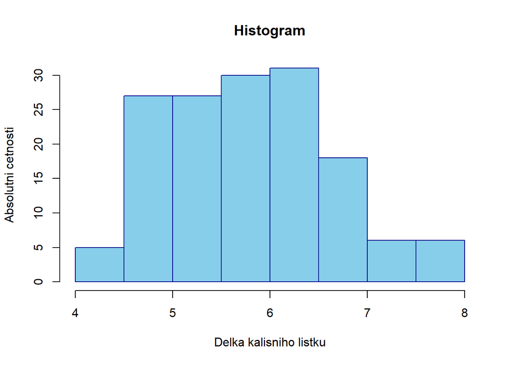

```r
kalisni.L <- iris$Sepal.Length

# histogram
hist(kalisni.L, main="Histogram", xlab = "Delka kalisniho listku", ylab = "Absolutni cetnosti",
    col = "skyblue", border = "darkblue")
```

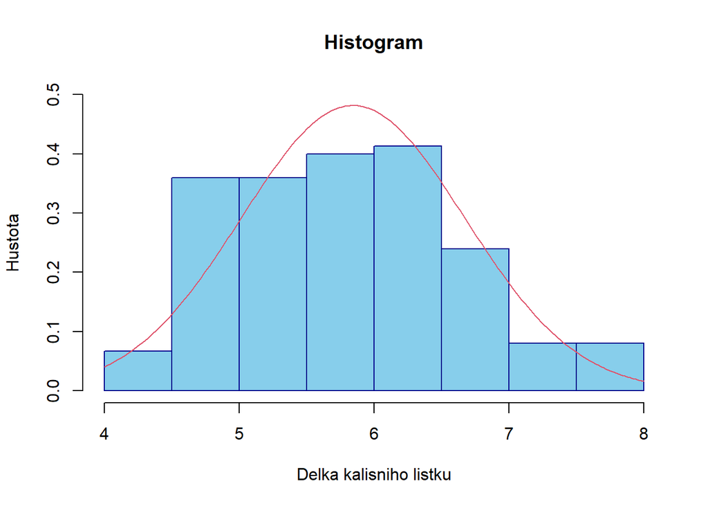

```r
  # s hustotou normalniho rozdeleni
  hist(kalisni.L ,main = "Histogram", xlab = "Delka kalisniho listku", ylab = "Hustota",
    col = "skyblue", border = "darkblue", freq = F, ylim = c(0, 0.5))
    # je treba vykreslit histogram prepocteny na hustotu
  lines(x <- seq(4, 8, by = 0.02), dnorm(x, mean(kalisni.L), sd(kalisni.L)), col = 2)
```

```r
    # jak sloupce odpovidaji Gaussove krivce?
    # jake muzeme cekat hodnoty sikmosti a spicatosti?
```

Ciselne charakteristiky tvaru rozdeleni

```r
cat("Sikmost =", Skew(kalisni.L), "\n")
```

```
## Sikmost = 0.3086407
```

```r
  # hranicni kladna sikmost - mirne pravostranne sesikmeni
cat("Spicatost =", Kurt(kalisni.L), "\n")
```

```
## Spicatost = -0.6058125
```

```r
  # zaporna spicatost (mensi nez -0.5) znaci rozdeleni, ktere je plozsi nez normalni (platykurticke)
```

Q-Q plot

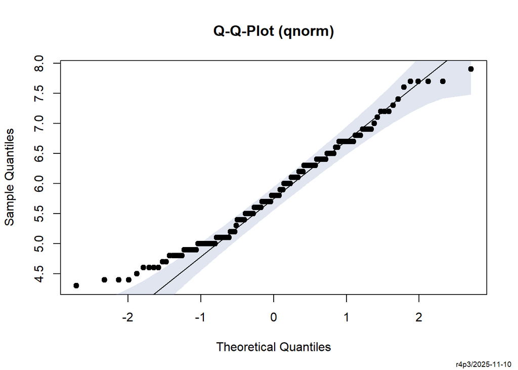

```r
# Graficky test normality: Q-Q plot - Quantile Comparison plot
PlotQQ(kalisni.L, pch = 19)
```

```r
  # na x-ove ose jsou teoreticke kvantily normalniho rozdeleni,
  #   na y-ove ose jsou namerene kvantily nasi promenne
  # pokud body lezi na primce, odpovida to normalnimu rozdeleni
  # zde jsou do pismene S - to znaci zapornou spicatost
  # jake dalsi tvary muze Q-Q plot mit?
```

Ciselne testy normality pro “rozumne” velka data (cca od 50 do 300 pozorovani)

Statisticky test: testuji se proti sobe 2 hypotezy: nulova a alternativni nulova hypoteza, H0: obsahuje jednu hodnotu, jednu variantu/ moznost alternativni hypoteza H1: obsahuje interval hodnot, vice moznosti, nekonkretni moznost testuje se na hladine vyznamnosti alfa (nejcasteji 5%) testy budeme vyhodnocovat na zaklade p-hodnoty POKUD JE P-HODNOTA <= ALFA, PAK H0 ZAMITAME, plati H1 POKUD JE P-HODNOTA > ALFA, PAK H0 NEZAMITAME jak si predstavit p-hodnotu pst naseho vysledku, pokud ve skutecnosti plati nulova hypoteza

```r
# Testujeme
#   H0: data maji normalni rozdeleni vs. H1: data nemaji normalni rozdeleni
shapiro.test(kalisni.L)
```

```
##
##  Shapiro-Wilk normality test
##
## data:  kalisni.L
## W = 0.97609, p-value = 0.01018
```

```r
  # p-hodnota 0.01018 < alfa 0.05 => H0 zamitame
  # data nemaji normalni rozdeleni
  LillieTest(kalisni.L)
```

```
##
##  Lilliefors (Kolmogorov-Smirnov) normality test
##
## data:  kalisni.L
## D = 0.088654, p-value = 0.005788
```

```r
  AndersonDarlingTest(kalisni.L, "pnorm", mean = mean(kalisni.L), sd = sd(kalisni.L))
```

```
##
##  Anderson-Darling test of goodness-of-fit
##  Null hypothesis: Normal distribution
##  with parameters mean = 5.843, sd = 0.828
##
## data:  kalisni.L
## An = 0.8892, p-value = 0.4208
```

```r
    # testu existuje vice
```

Overte normalitu pro promenne Sepal.Width a Petal.Length z databaze iris a pro promenne Ozone a Temp (teplota) z databaze airquality

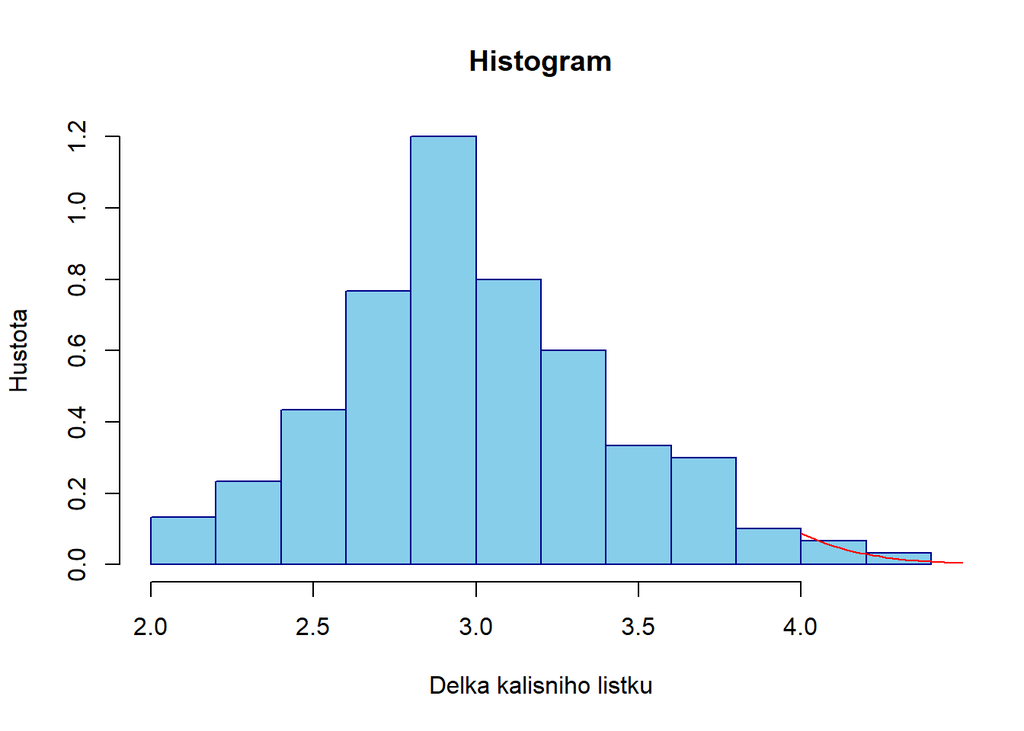

```r
kalisni.W <- iris$Sepal.Width

hist(kalisni.W ,main = "Histogram", xlab = "Delka kalisniho listku", ylab = "Hustota",
  col = "skyblue", border = "darkblue", freq = F)
  # je treba vykreslit histogram prepocteny na hustotu
lines(x <- seq(4, 8, by = 0.02), dnorm(x, mean(kalisni.W), sd(kalisni.W)), col = "red")
```

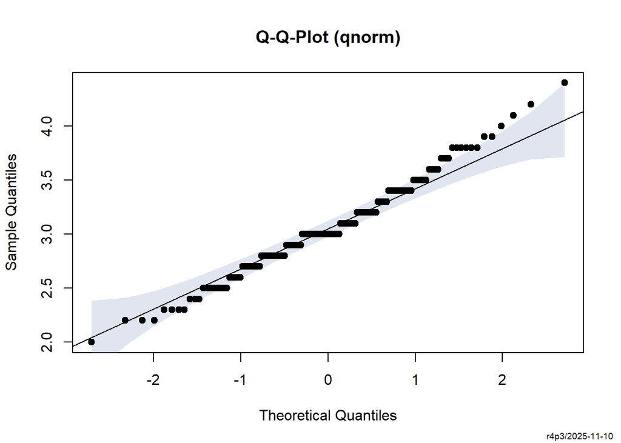

```r
PlotQQ(kalisni.W, pch = 19)
```

```r
LillieTest(kalisni.W)
```

```
##
##  Lilliefors (Kolmogorov-Smirnov) normality test
##
## data:  kalisni.W
## D = 0.10566, p-value = 0.0003142
```

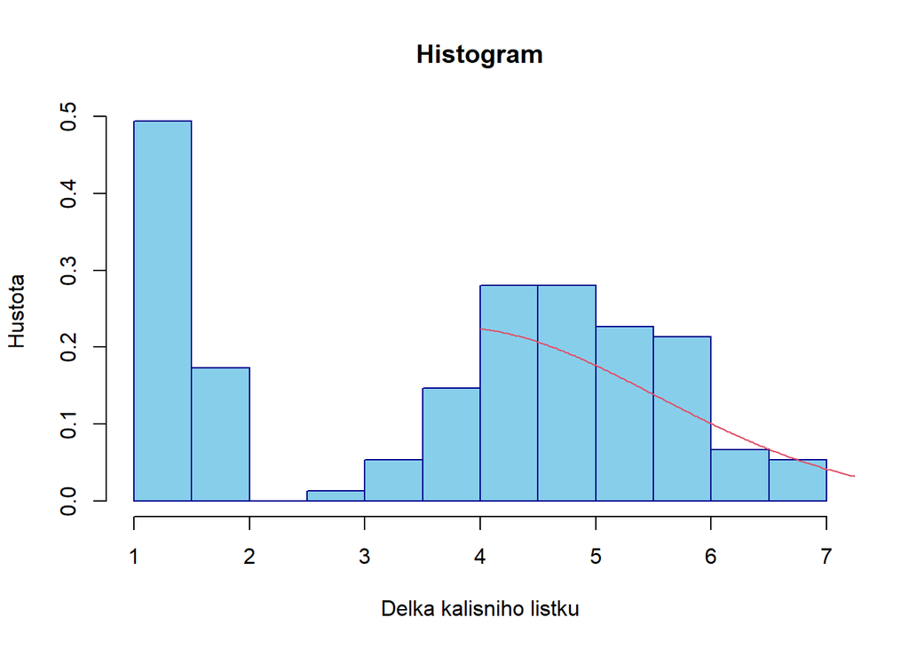

```r
korunni.L <- iris$Petal.Length

hist(korunni.L ,main = "Histogram", xlab = "Delka kalisniho listku", ylab = "Hustota",
  col = "skyblue", border = "darkblue", freq = F)
  # je treba vykreslit histogram prepocteny na hustotu
lines(x <- seq(4, 8, by = 0.02), dnorm(x, mean(korunni.L), sd(korunni.L)), col = 2)
```

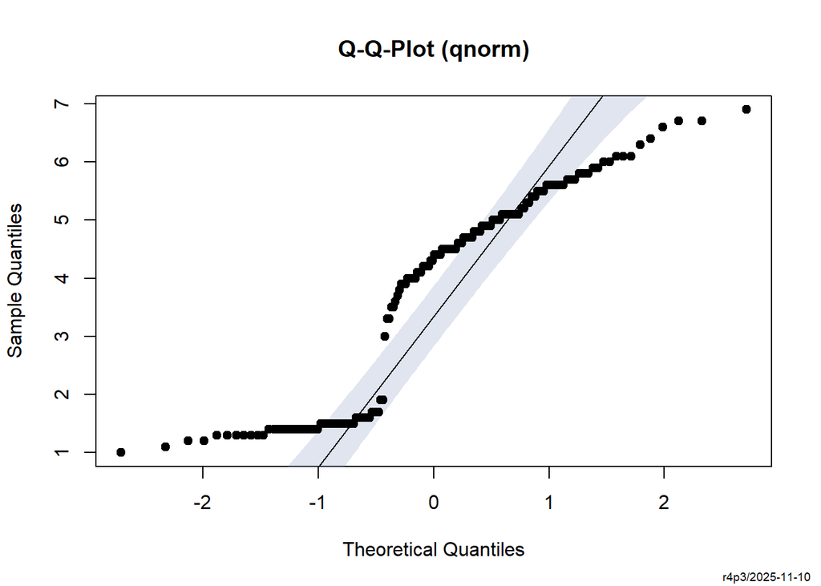

```r
PlotQQ(korunni.L, pch = 19)
```

```r
LillieTest(korunni.L)
```

```
##
##  Lilliefors (Kolmogorov-Smirnov) normality test
##
## data:  korunni.L
## D = 0.19815, p-value = 7.901e-16
```

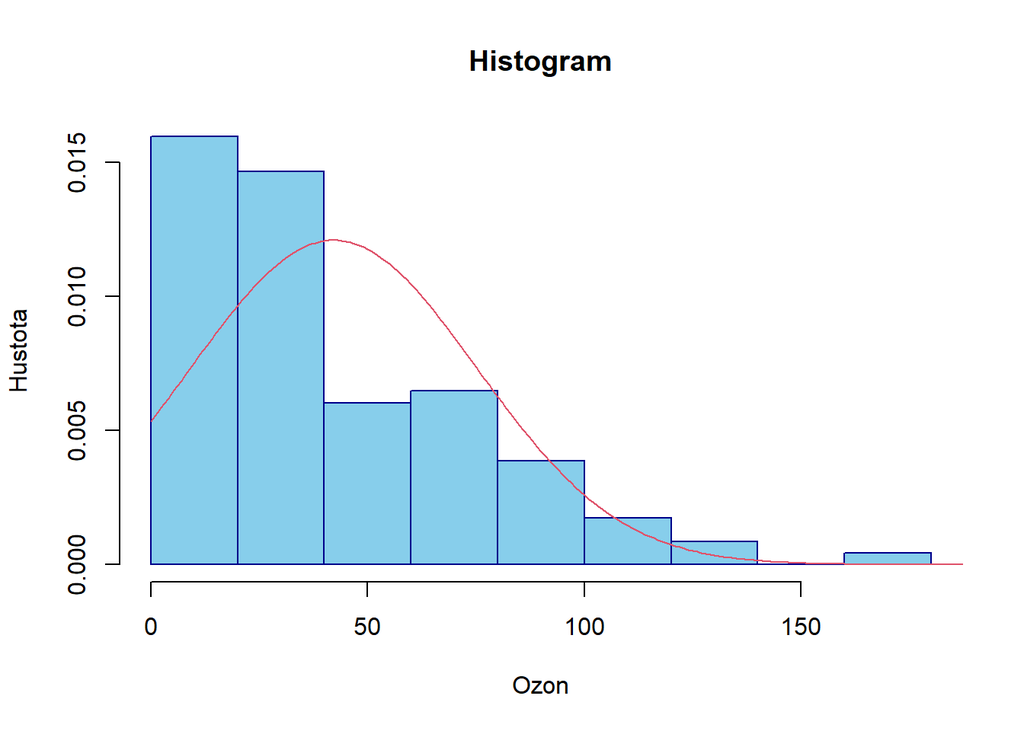

```r
ozon <- airquality$Ozone

hist(ozon ,main = "Histogram", xlab = "Ozon", ylab = "Hustota",
  col = "skyblue", border = "darkblue", freq = F)
  # je treba vykreslit histogram prepocteny na hustotu
lines(x <- seq(0, 200, by = 1), dnorm(x, mean(ozon, na.rm=TRUE), sd(ozon, na.rm=TRUE)), col = 2)
```

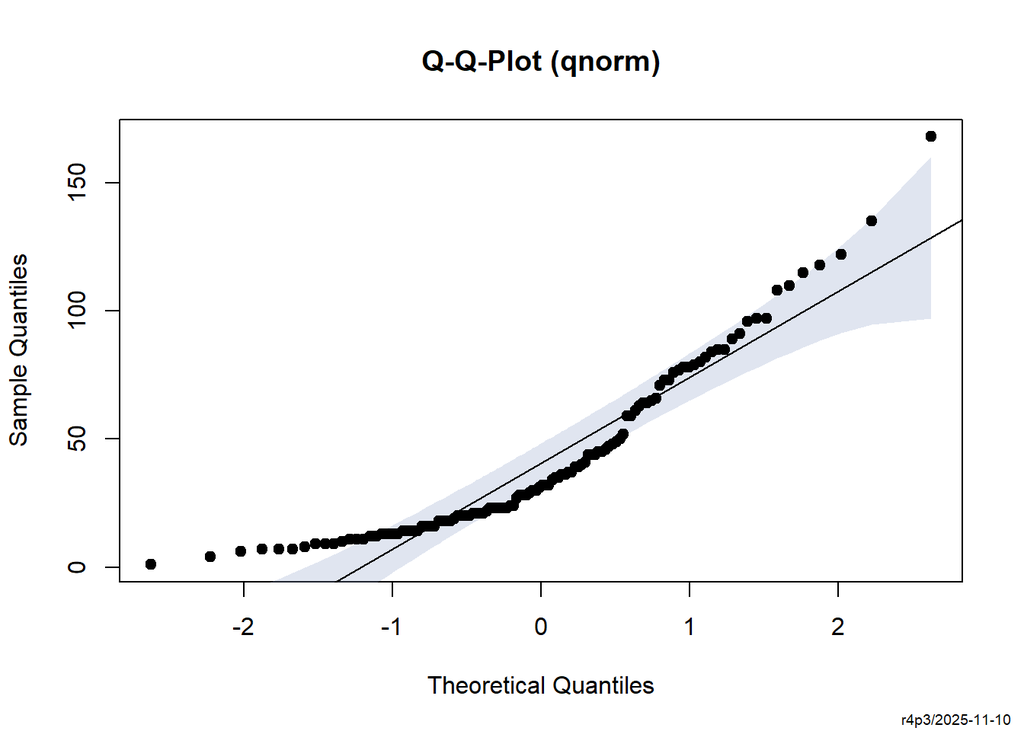

```r
PlotQQ(ozon, pch = 19)
```

```r
LillieTest(ozon)
```

```
##
##  Lilliefors (Kolmogorov-Smirnov) normality test
##
## data:  ozon
## D = 0.14799, p-value = 1.47e-06
```

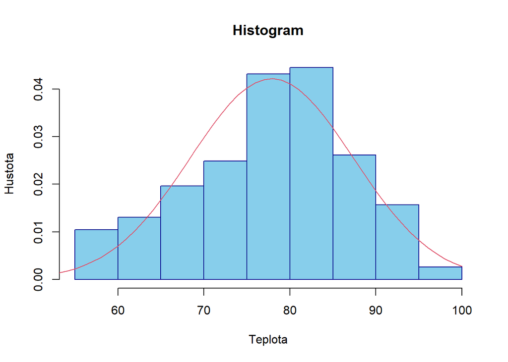

```r
teplota <- airquality$Temp

hist(teplota ,main = "Histogram", xlab = "Teplota", ylab = "Hustota",
  col = "skyblue", border = "darkblue", freq = F)
  # je treba vykreslit histogram prepocteny na hustotu
lines(x <- seq(50, 100, by = 1), dnorm(x, mean(teplota, na.rm=TRUE), sd(teplota, na.rm=TRUE)), col = 2)
```

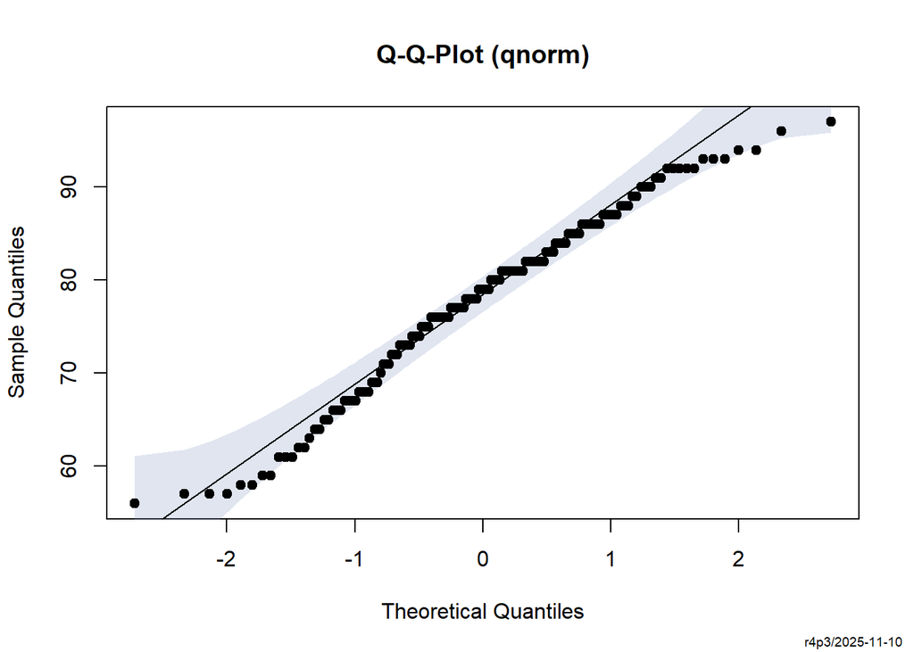

```r
PlotQQ(teplota, pch = 19)
```

```r
LillieTest(teplota)
```

```
##
##  Lilliefors (Kolmogorov-Smirnov) normality test
##
## data:  teplota
## D = 0.081313, p-value = 0.01506
```

Centralni limitni veta soucet nezavislych stejne rozdelenych nahodnych velicin konverguje k normalnimu rozdeleni pro pocet pozorovani rostouci nade vsechny meze

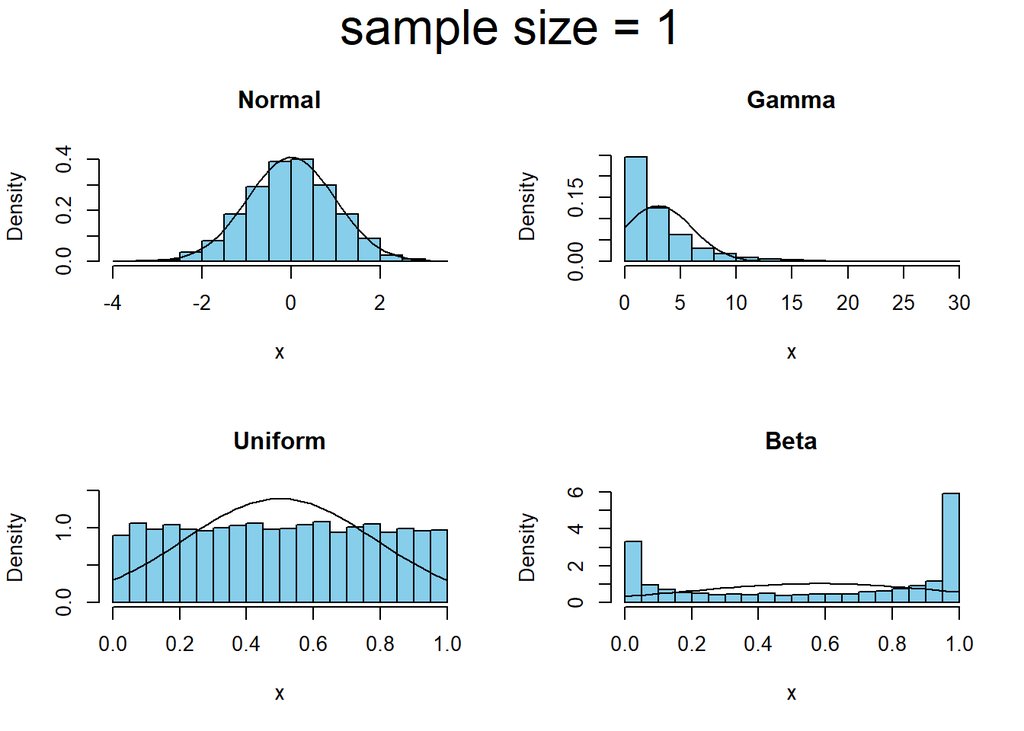

```r
clt.examp(1)
```

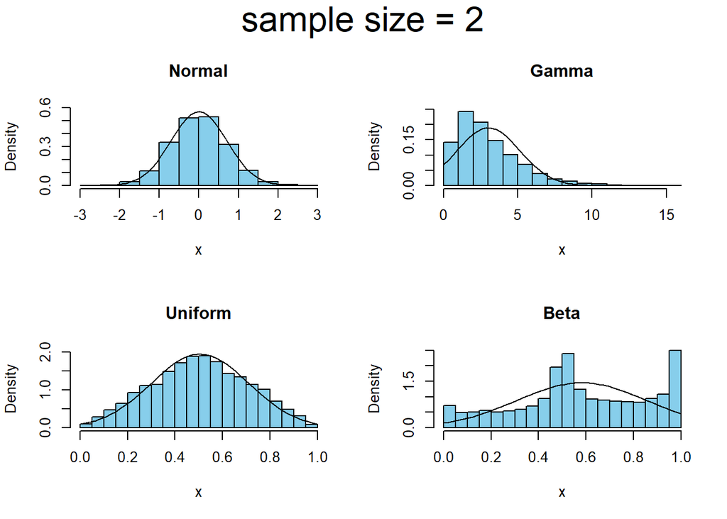

```r
clt.examp(2)
```

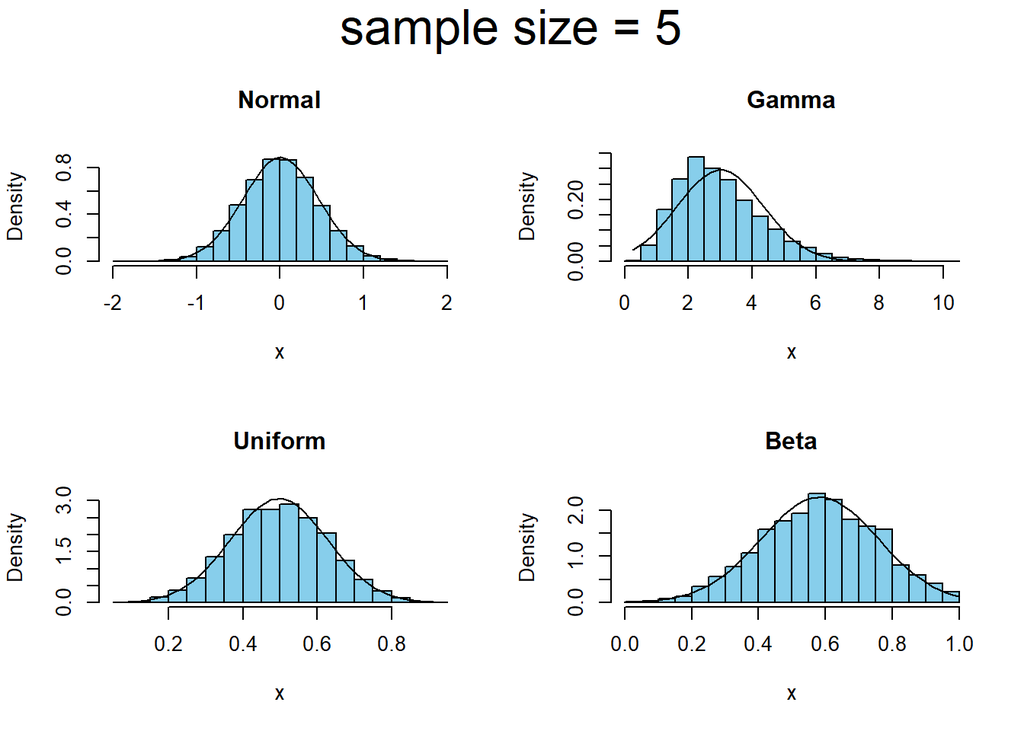

```r
clt.examp(5)
```

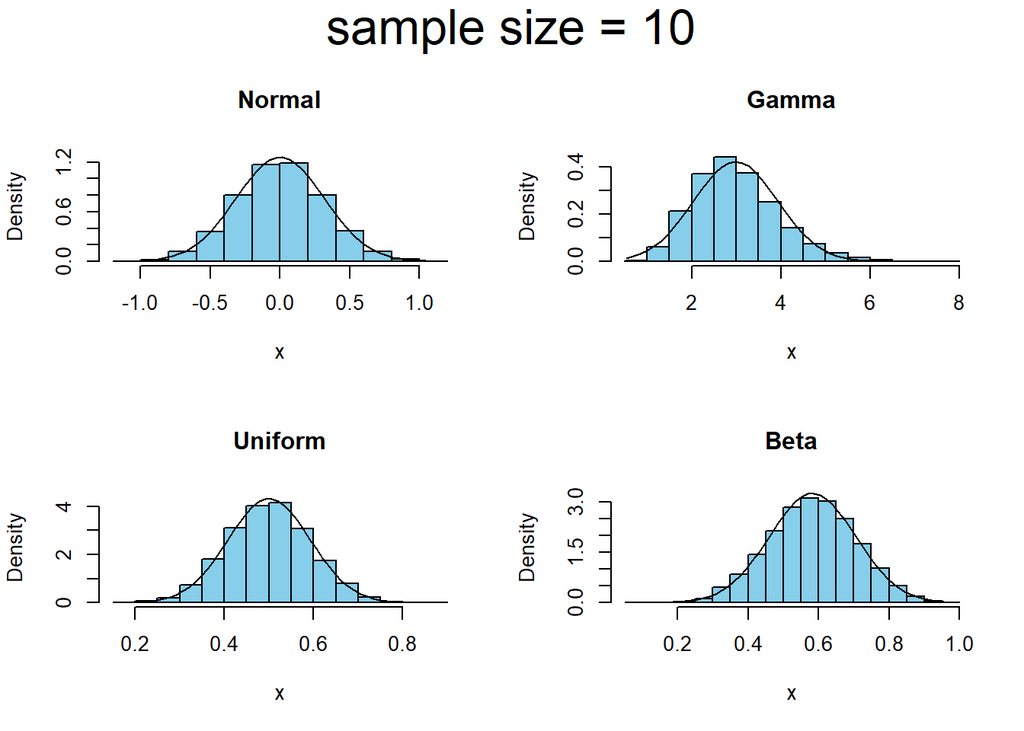

```r
clt.examp(10)
```

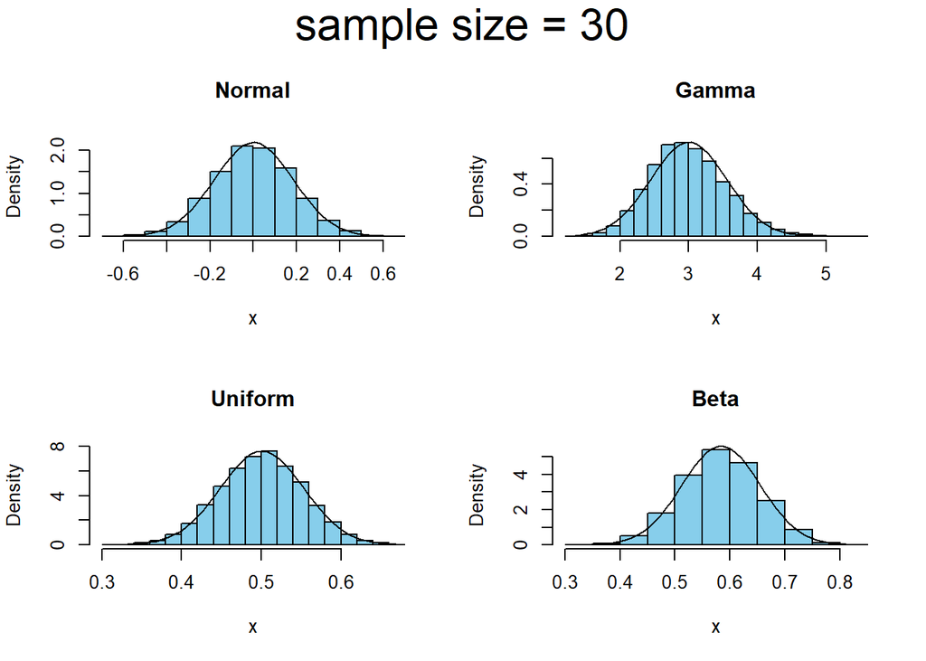

```r
clt.examp(30)
```

Binomicke rozdeleni: n - pocet pokusu, p - pst uspechu pbinom(k, n, p) - distribucni funkce dbinom(k, n, p) - pravdepodobnostni funcke

Hypergeometricke rozdeleni: w - pocet bilych kouli v osudi, b - pocet cernych kouli v osudi n - pocet kouli tazenych z osudi phyper(k, w, b, n) - distribucni funkce dhyper(k, w, b, n) - pravdepodobnostni funcke

Geometricke rozdeleni: p - pravdepodobnost uspechu pgeom(k, p) - distribucni funkce dgeom(k, p) - pravdepodobnostni funcke

Poissonovo rozdeleni: lambda - stredni hodnota ppois(k, lambda) - distribucni funkce dpois(k, lambda) - pravdepodobnostni funcke

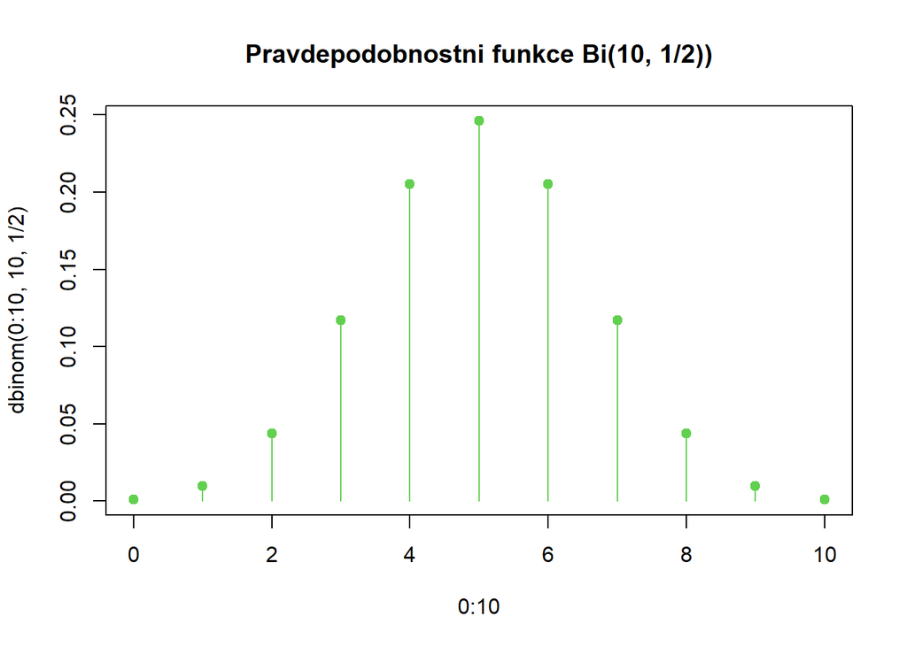

```r
## Binomicke rozdeleni
# Hazim desetkrat minci, jaka je pravdepodobnost, ze mi padne x krat orel?

# pravdepodobnostni funkce
plot(0:10, dbinom(0:10, 10, 1/2), col = 3, type = "h", main = "Pravdepodobnostni funkce Bi(10, 1/2))")
points(0:10, dbinom(0:10, 10, 1/2), col = 3, pch = 19)
```

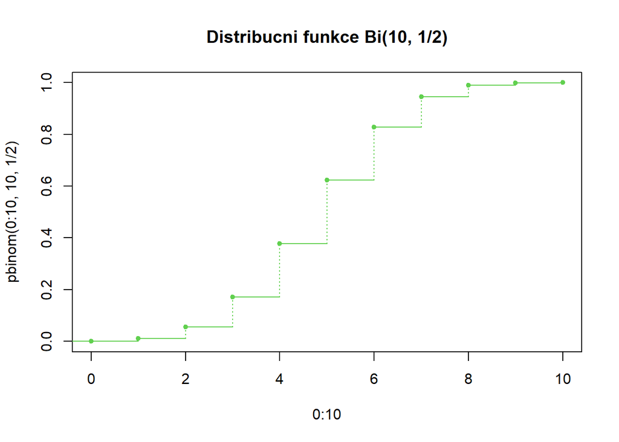

```r
# distribucni funkce
plot(0:10, pbinom(0:10, 10, 1/2), col = 3, ylim = c(0,1), pch = 20, main = "Distribucni funkce Bi(10, 1/2)")
for(i in 0:10){
 lines(c((i-1),i), c(pbinom(i-1, 10, 1/2), pbinom(i-1, 10, 1/2)), col = 3)
 lines(c(i,i), c(pbinom(i-1, 10, 1/2), pbinom(i, 10, 1/2)), col = 3, lty = 3)
}
```

```r
# pravdepodobnostni funkce
# pst, ze padne 6 krat orel
cat("P(X = 6)", dbinom(6, 10, 1/2), "\n", "\n")
```

```
## P(X = 6) 0.2050781
##
```

```r
# pst, ze padne maximalne 3 krat orel
cat("P(X <= 3)", pbinom(3, 10, 1/2), "\n")
```

```
## P(X <= 3) 0.171875
```

```r
cat("P(X <= 3)", sum(dbinom(0:3, 10, 1/2)), "\n", "\n")
```

```
## P(X <= 3) 0.171875
##
```

```r
# pst, ze padne vice nez 4 krat orel
cat("P(X > 4)", 1 - pbinom(4, 10, 1/2), "\n")
```

```
## P(X > 4) 0.6230469
```

```r
cat("P(X > 4)", sum(dbinom(5:10, 10, 1/2)), "\n", "\n")
```

```
## P(X > 4) 0.6230469
##
```

```r
# pst, ze padne mene nez 6 krat orel
cat("P(X < 6)", pbinom(5, 10, 1/2), "\n")
```

```
## P(X < 6) 0.6230469
```

```r
cat("P(X < 6)", sum(dbinom(0:5, 10, 1/2)), "\n", "\n")
```

```
## P(X < 6) 0.6230469
##
```

```r
# pst, ze padne alespon 7 krat orel
cat("P(X >= 7)", 1 - pbinom(6, 10, 1/2), "\n")
```

```
## P(X >= 7) 0.171875
```

```r
cat("P(X >= 7)", sum(dbinom(7:10, 10, 1/2)), "\n", "\n")
```

```
## P(X >= 7) 0.171875
##
```

```r
# pst, ze padne alespon 3 krat a maximalne 6 krat orel
cat("P(3 <= X <= 6)", pbinom(6, 10, 1/2) - pbinom(2, 10, 1/2), "\n")
```

```
## P(3 <= X <= 6) 0.7734375
```

```r
cat("P(3 <= X <= 6)", sum(dbinom(3:6, 10, 1/2)), "\n", "\n")
```

```
## P(3 <= X <= 6) 0.7734375
##
```

Student rano zaspi s pravdepodobnosti 0.1. Semestr ma 12 tydnu. Jaka je pravdepodobnost, ze z techto dnanacti prednasek zaspi presne trikrat? Ze zaspi maximalne petkrat? Ze prijde na vetsinu prednasek vcas?

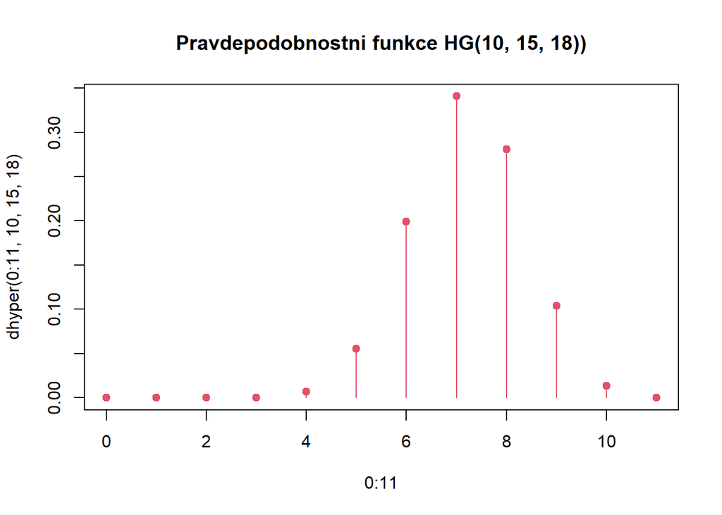

```r
## Hypergeometricke rozdeleni
# Na parkovisti stoji 10 vozu znacky Skoda a 15 vozu jine znacky.
# Jaka je pravdepodobnost, ze kdyz 7 aut odjede, zbude na parkovisti xx aut znacky Skoda.

# pravdepodobnostni funkce
plot(0:11, dhyper(0:11, 10, 15, 18), col = 2, type = "h", main = "Pravdepodobnostni funkce HG(10, 15, 18))")
points(0:11, dhyper(0:11, 10, 15, 18), col = 2, pch = 19)
```

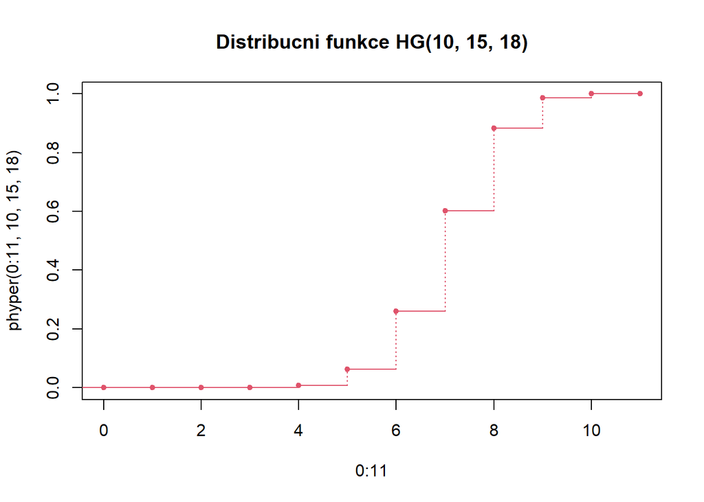

```r
# distribucni funkce
plot(0:11, phyper(0:11, 10, 15, 18), col = 2, ylim = c(0,1), pch = 20, main = "Distribucni funkce HG(10, 15, 18)")
for(i in 0:11){
 lines(c((i-1),i), c(phyper(i-1, 10, 15, 18), phyper(i-1, 10, 15, 18)), col = 2)
 lines(c(i,i), c(phyper(i-1, 10, 15, 18), phyper(i, 10, 15, 18)), col = 2, lty = 3)
}
```

Jaka je pravdepodobnost, ze zbude 8 Skodovek? Ze Skodovek vyjede maximalne 5? Ze zbude alespon 6 a maximalne 10 Skodovek? Ze zbude alespon 6 Skodovek? Ze vzjede 7 aut jine znackz nez Skoda?

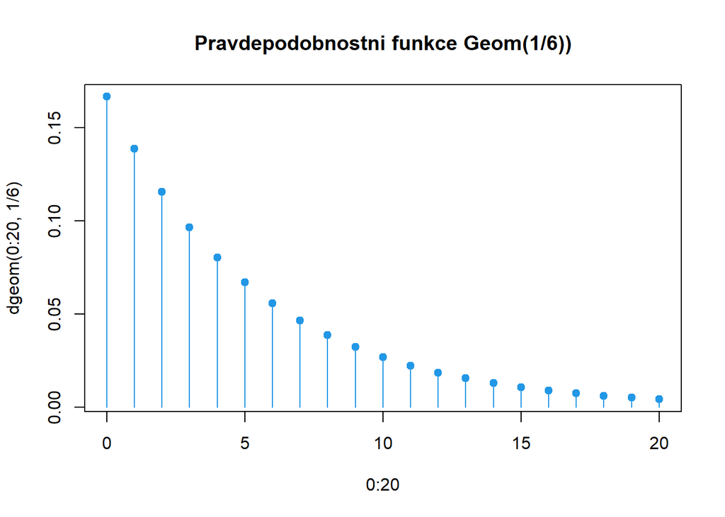

```r
## Geometricke rozdeleni
# Hazite sestistennou kostkou a ptate se, jaka je pst, ze sestka padne prvne v xx-tem hodu.
# Pocita se pocet neuspechu pred prvnim uspechem.

# pravdepodobnostni funkce
plot(0:20, dgeom(0:20, 1/6), col = 4, type = "h", main = "Pravdepodobnostni funkce Geom(1/6))")
points(0:20, dgeom(0:20, 1/6), col = 4, pch = 19)
```

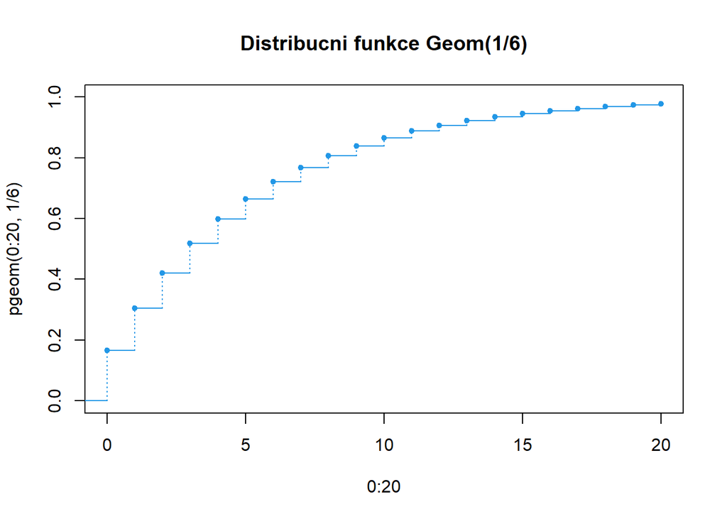

```r
# distribucni funkce
plot(0:20, pgeom(0:20, 1/6), col = 4, ylim = c(0,1), pch = 20, main = "Distribucni funkce Geom(1/6)")
for(i in 0:20){
 lines(c((i-1),i), c(pgeom(i-1, 1/6), pgeom(i-1, 1/6)), col = 4)
 lines(c(i,i), c(pgeom(i-1, 1/6), pgeom(i, 1/6)), col = 4, lty = 3)
}
```

Jaka je pravdepodobnost, ze sestka padne prvne ve tretim pokusu? Ze padne nejpozdeji v desatem pokusu? Ze padne prvne mezi ctvrtym a sestym hodem?

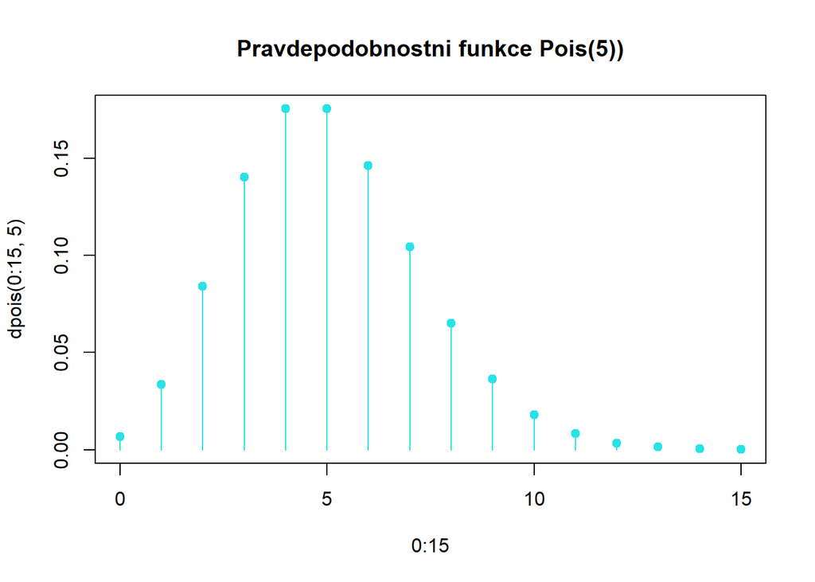

```r
## Poissonovo rozdeleni
# Do obchudku prijde prumerne 5 lidi za hodinu. Jaka je ravdepodobnost, ze jich za hodinu prijde presne xx?

# pravdepodobnostni funkce
plot(0:15, dpois(0:15, 5), col = 5, type = "h", main = "Pravdepodobnostni funkce Pois(5))")
points(0:15, dpois(0:15, 5), col = 5, pch = 19)
```

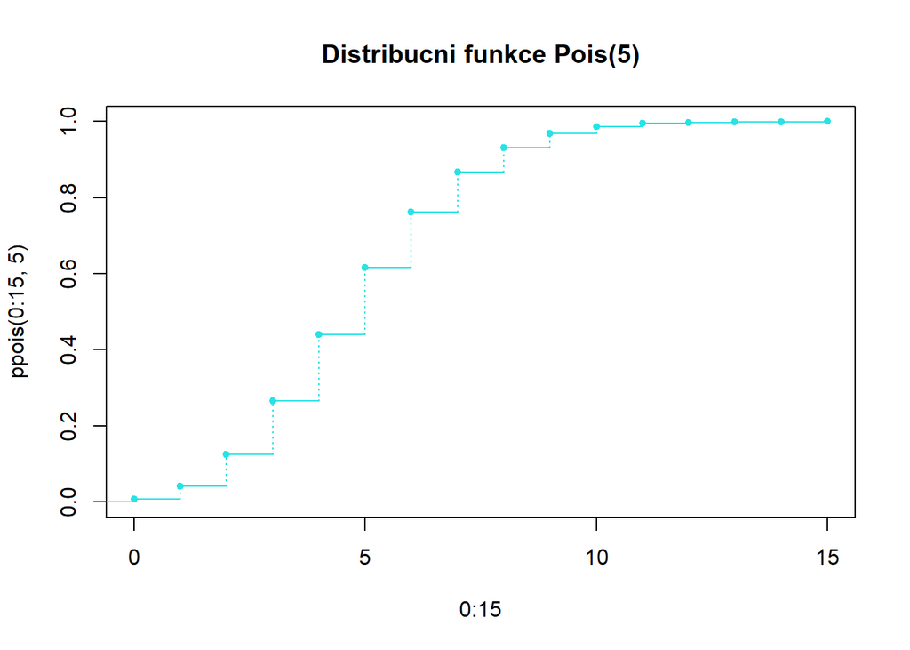

```r
# distribucni funkce
plot(0:15, ppois(0:15, 5), col = 5, ylim = c(0,1), pch = 20, main = "Distribucni funkce Pois(5)")
for(i in 0:15){
 lines(c((i-1),i), c(ppois(i-1, 5), ppois(i-1, 5)), col = 5)
 lines(c(i,i), c(ppois(i-1, 5), ppois(i, 5)), col = 5, lty = 3)
}
```

Jaka je pravdepodobnost, ze jich prijde za hodinu 8? Ze prijdou mene nez 3? Ze za 2 hodiny jich prijde alespon 12?